# anushab_hw3

```python
# 1b: load dataset

# copy file path from the datasets bucket
gcs_path = "gs://msca-31013-bdp-ap-datasets/Crimes_-_2001_to_Present.csv"

# Read the CSV file using path
crimes_df = spark.read.csv(gcs_path, header=True, inferSchema=True)

# display first few rows of data frame to check loading
crimes_df.show(10)
```

```
+--------+-----------+--------------------+--------------------+----+------------------+--------------------+--------------------+------+--------+----+--------+----+--------------+--------+------------+------------+----+--------------------+--------+---------+--------+
|      ID|Case Number|                Date|               Block|IUCR|      Primary Type|         Description|Location Description|Arrest|Domestic|Beat|District|Ward|Community Area|FBI Code|X Coordinate|Y Coordinate|Year|          Updated On|Latitude|Longitude|Location|
+--------+-----------+--------------------+--------------------+----+------------------+--------------------+--------------------+------+--------+----+--------+----+--------------+--------+------------+------------+----+--------------------+--------+---------+--------+
|11037294|   JA371270|03/18/2015 12:00:...|   0000X W WACKER DR|1153|DECEPTIVE PRACTICE|FINANCIAL IDENTIT...|                BANK| false|   false| 111|       1|  42|            32|      11|        null|        null|2015|08/01/2017 03:52:...|    null|     null|    null|
|11646293|   JC213749|12/20/2018 03:00:...|023XX N LOCKWOOD AVE|1154|DECEPTIVE PRACTICE|FINANCIAL IDENTIT...|           APARTMENT| false|   false|2515|      25|  36|            19|      11|        null|        null|2018|04/06/2019 04:04:...|    null|     null|    null|
|11645836|   JC212333|05/01/2016 12:25:...| 055XX S ROCKWELL ST|1153|DECEPTIVE PRACTICE|FINANCIAL IDENTIT...|                null| false|   false| 824|       8|  15|            63|      11|        null|        null|2016|04/06/2019 04:04:...|    null|     null|    null|
|11645959|   JC211511|12/20/2018 04:00:...|  045XX N ALBANY AVE|2820|     OTHER OFFENSE|    TELEPHONE THREAT|           RESIDENCE| false|   false|1724|      17|  33|            14|     08A|        null|        null|2018|04/06/2019 04:04:...|    null|     null|    null|
|11645601|   JC212935|06/01/2014 12:01:...| 087XX S SANGAMON ST|1153|DECEPTIVE PRACTICE|FINANCIAL IDENTIT...|           RESIDENCE| false|   false|2222|      22|  21|            71|      11|        null|        null|2014|04/06/2019 04:04:...|    null|     null|    null|
|11646166|   JC213529|09/01/2018 12:01:...|082XX S INGLESIDE...|0810|             THEFT|           OVER $500|           RESIDENCE| false|    true| 631|       6|   8|            44|      06|        null|        null|2018|04/06/2019 04:04:...|    null|     null|    null|
|11645648|   JC212959|01/01/2018 08:00:...| 024XX N MONITOR AVE|1153|DECEPTIVE PRACTICE|FINANCIAL IDENTIT...|           RESIDENCE| false|   false|2515|      25|  30|            19|      11|        null|        null|2018|04/06/2019 04:04:...|    null|     null|    null|
|11645557|   JC212685|04/01/2018 12:01:...|  080XX S VERNON AVE|1153|DECEPTIVE PRACTICE|FINANCIAL IDENTIT...|           RESIDENCE| false|   false| 631|       6|   6|            44|      11|        null|        null|2018|04/06/2019 04:04:...|    null|     null|    null|
|11645527|   JC212744|02/02/2015 10:00:...|  069XX W ARCHER AVE|1153|DECEPTIVE PRACTICE|FINANCIAL IDENTIT...|               OTHER| false|   false| 811|       8|  23|            56|      11|        null|        null|2015|04/06/2019 04:04:...|    null|     null|    null|
|11645833|   JC213044|05/05/2012 12:25:...|     057XX W OHIO ST|1153|DECEPTIVE PRACTICE|FINANCIAL IDENTIT...|                null| false|   false|1511|      15|  29|            25|      11|        null|        null|2012|04/06/2019 04:04:...|    null|     null|    null|
+--------+-----------+--------------------+--------------------+----+------------------+--------------------+--------------------+------+--------+----+--------+----+--------------+--------+------------+------------+----+--------------------+--------+---------+--------+
only showing top 10 rows
```

```python
# 1c: summary statististics
crimes_df.describe().show()
```

```
+-------+-----------------+------------------+--------------------+--------------+------------------+-----------------+---------------+--------------------+------------------+-----------------+------------------+------------------+------------------+------------------+-----------------+-------------…
|summary|               ID|       Case Number|                Date|         Block|              IUCR|     Primary Type|    Description|Location Description|              Beat|         District|              Ward|    Community Area|          FBI Code|      X Coordinate|     Y Coordinate|             …
+-------+-----------------+------------------+--------------------+--------------+------------------+-----------------+---------------+--------------------+------------------+-----------------+------------------+------------------+------------------+------------------+-----------------+-------------…
|  count|          8177112|           8177112|             8177112|       8177112|           8177112|          8177112|        8177112|             8163474|           8177112|          8177065|           7562282|           7563658|           8177112|           8087141|          8087141|           81…
|   mean|7327719.370262386|          277222.5|                null|          null|1117.7040835057032|             null|           null|                null|1184.6041316298467| 11.2976073933618|22.774896387095854| 37.41704966036275|12.014347895703695|1164629.4186788632|1885868.779656618|2010.59314462…
| stddev|3674549.881318547|155025.77649001902|                null|          null| 810.5968725354505|             null|           null|                null| 703.5599060021582|6.960087533831332|13.856180148951827|21.547193292488448| 7.284259116430808|16972.112249927384|32460.31991330238| 6.7600415575…
|    min|              634|         01G050460|01/01/2001 01:00:...|0000X E 100 PL|              0110|            ARSON| $300 AND UNDER|"CTA ""L"" PLATFORM"|               111|                1|                 1|                 0|               01A|                 0|                0|             …
|    max|         13630172|         ZZZ199957|12/31/2023 12:55:...|   XX  UNKNOWN|              9901|WEAPONS VIOLATION|WIREROOM/SPORTS|                YMCA|              2535|               31|                50|                77|                27|           1205119|          1951622|             …
+-------+-----------------+------------------+--------------------+--------------+------------------+-----------------+---------------+--------------------+------------------+-----------------+------------------+------------------+------------------+------------------+-----------------+-------------…
```

```python
# 1d: partitioning

# Get the size of each partition
def displaypartitions(df):
    num = df.rdd.getNumPartitions()
    print("Partitions:", num)
    df.withColumn("partitionId", F.spark_partition_id())\
        .groupBy("partitionId")\
        .count()\
        .orderBy(F.asc("count"))\
        .show(num)

displaypartitions(crimes_df)
```

```
Partitions: 15
```

```
[Stage 6:==================================>                       (9 + 6) / 15]
```

```
+-----------+------+
|partitionId| count|
+-----------+------+
|         14|220162|
|          0|562341|
|          1|563845|
|         13|565129|
|         12|565243|
|         11|565553|
|         10|566319|
|          9|567375|
|          7|567552|
|          2|567641|
|          8|568526|
|          6|568632|
|          3|568800|
|          5|577463|
|          4|582531|
+-----------+------+
```

##### There are 15 total partitions. The partition size for partition 14 is uneven compared to all of the other partitions (~220,000 v.s. 560,000-580,000). So, we will need to repartition the data.

```python
#re-partition the data
crimes_df_new = crimes_df.repartition(15)
displaypartitions(crimes_df_new)
```

```
[Stage 9:=================================================>       (13 + 2) / 15]
```

```
Partitions: 15
```

```
[Stage 12:==============================>                          (8 + 7) / 15]
```

```
+-----------+------+
|partitionId| count|
+-----------+------+
|          0|545136|
|         14|545136|
|         13|545137|
|          1|545137|
|         12|545139|
|          2|545139|
|          3|545141|
|         11|545141|
|         10|545143|
|          5|545143|
|          4|545143|
|          9|545144|
|          6|545144|
|          7|545144|
|          8|545145|
+-----------+------+
```

##### The partitions are now evenly distributed in size, so, further repartitioning is not needed.

## Question 2

```python
# 2a: drop columns beat, ward, longitude, and latitude

crimes_df = crimes_df.drop("Beat", "Ward", "Longitude", "Latitude")
```

```python
# make sure the columns are dropped
crimes_df.columns
```

```
['ID',
 'Case Number',
 'Date',
 'Block',
 'IUCR',
 'Primary Type',
 'Description',
 'Location Description',
 'Arrest',
 'Domestic',
 'District',
 'Community Area',
 'FBI Code',
 'X Coordinate',
 'Y Coordinate',
 'Year',
 'Updated On',
 'Location']
```

##### The columns were successfully dropped since we don't see them in the list of columns after dropping them.

```python
# 2b: convert remaining columns to appropriate data types

# first check data types of each column
crimes_df.printSchema()
```

```
root
 |-- ID: integer (nullable = true)
 |-- Case Number: string (nullable = true)
 |-- Date: string (nullable = true)
 |-- Block: string (nullable = true)
 |-- IUCR: string (nullable = true)
 |-- Primary Type: string (nullable = true)
 |-- Description: string (nullable = true)
 |-- Location Description: string (nullable = true)
 |-- Arrest: boolean (nullable = true)
 |-- Domestic: boolean (nullable = true)
 |-- District: integer (nullable = true)
 |-- Community Area: integer (nullable = true)
 |-- FBI Code: string (nullable = true)
 |-- X Coordinate: integer (nullable = true)
 |-- Y Coordinate: integer (nullable = true)
 |-- Year: integer (nullable = true)
 |-- Updated On: string (nullable = true)
 |-- Location: string (nullable = true)
```

```python
# next inspect each column and see the values
# compare values to the data types to see what needs to be converted
crimes_df.select("ID").show(10)
crimes_df.select("Case Number").show(10)
crimes_df.select("Date").show(10)
crimes_df.select("Block").show(10)
crimes_df.select("IUCR").show(10)
crimes_df.select("Primary Type").show(10)
crimes_df.select("Description").show(10)
crimes_df.select("Location Description").show(10)
crimes_df.select("Arrest").show(10)
crimes_df.select("Domestic").show(10)
crimes_df.select("District").show(10)
crimes_df.select("Community Area").show(10)
crimes_df.select("FBI Code").show(10)
crimes_df.select("X Coordinate").show(20)
crimes_df.select("Y Coordinate").show(20)
crimes_df.select("Year").show(10)
crimes_df.select("Updated On").show(10)
crimes_df.select("Location").show(20)
```

```
+--------+
|      ID|
+--------+
|11037294|
|11646293|
|11645836|
|11645959|
|11645601|
|11646166|
|11645648|
|11645557|
|11645527|
|11645833|
+--------+
only showing top 10 rows

+-----------+
|Case Number|
+-----------+
|   JA371270|
|   JC213749|
|   JC212333|
|   JC211511|
|   JC212935|
|   JC213529|
|   JC212959|
|   JC212685|
|   JC212744|
|   JC213044|
+-----------+
only showing top 10 rows

+--------------------+
|                Date|
+--------------------+
|03/18/2015 12:00:...|
|12/20/2018 03:00:...|
|05/01/2016 12:25:...|
|12/20/2018 04:00:...|
|06/01/2014 12:01:...|
```

[output cut: 262 more lines]

```
|                null|
|                null|
|                null|
|                null|
|(41.830481843, -8...|
|(41.836310224, -8...|
|(41.747609555, -8...|
|(41.77487752, -87...|
|(41.781002663, -8...|
|                null|
|                null|
|                null|
|(41.746220584, -8...|
+--------------------+
only showing top 20 rows
```

##### The following columns need to be converted to new data types:

- ID, integer -> string (ID should not be changed and strings are an immutable data type)
- Date, string -> datetype (should be in date format)
- updated on, string -> datetype (should be in date format)
- IUCR, string -> integer (the values in this column are integers)

```python
# Convert ID column from integer to string
crimes_df = crimes_df.withColumn("ID", crimes_df["ID"].cast("string"))
```

```python
# Convert IUCR column from string to integer
crimes_df = crimes_df.withColumn("IUCR", crimes_df["IUCR"].cast("int"))
```

```python
# Convert Date and Updated on to appropriate date type
crimes_df = crimes_df.withColumn("Date", to_date("Date", "MM/dd/yyyy hh:mm:ss a"))

crimes_df = crimes_df.withColumn("Updated On", to_date("Updated On", "MM/dd/yyyy hh:mm:ss a"))
```

```python
# check that the types updated correctly for the three columns
crimes_df.printSchema()
```

```
root
 |-- ID: string (nullable = true)
 |-- Case Number: string (nullable = true)
 |-- Date: date (nullable = true)
 |-- Block: string (nullable = true)
 |-- IUCR: integer (nullable = true)
 |-- Primary Type: string (nullable = true)
 |-- Description: string (nullable = true)
 |-- Location Description: string (nullable = true)
 |-- Arrest: boolean (nullable = true)
 |-- Domestic: boolean (nullable = true)
 |-- District: integer (nullable = true)
 |-- Community Area: integer (nullable = true)
 |-- FBI Code: string (nullable = true)
 |-- X Coordinate: integer (nullable = true)
 |-- Y Coordinate: integer (nullable = true)
 |-- Year: integer (nullable = true)
 |-- Updated On: date (nullable = true)
 |-- Location: string (nullable = true)
```

```python
# checking that the dates updates correctly
crimes_df.select("Date").show(10, truncate = False)
```

```
+----------+
|Date      |
+----------+
|2015-03-18|
|2018-12-20|
|2016-05-01|
|2018-12-20|
|2014-06-01|
|2018-09-01|
|2018-01-01|
|2018-04-01|
|2015-02-02|
|2012-05-05|
+----------+
only showing top 10 rows
```

```python
# 2c: add month column and community names

# load in community names data set

# get file path from the bucket
gcs_path = "gs://msca-31013-bdp-ap-datasets/Community Areas.csv"

# Read the CSV file using path
comms_df = spark.read.csv(gcs_path, header=True, inferSchema=True)


# display first few rows of data frame to check loading
comms_df.show(10)
```

```
+---+---------------+----------+-------+-------+----------+----------+
| no|           name|population|area_sq|area_km|density_sq|density_km|
+---+---------------+----------+-------+-------+----------+----------+
|  1|    Rogers Park|    55,628|   1.84|   4.77| 30,232.61| 11,672.81|
|  2|     West Ridge|    77,122|   3.53|   9.14| 21,847.59|  8,435.36|
|  3|         Uptown|    57,182|   2.32|   6.01| 24,647.41|  9,516.37|
|  4| Lincoln Square|    40,494|   2.56|   6.63| 15,817.97|  6,107.32|
|  5|   North Center|    35,114|   2.05|   5.31| 17,128.78|  6,613.42|
|  6|      Lake View|   103,050|   3.12|   8.08| 33,028.85| 12,752.44|
|  7|   Lincoln Park|    70,492|   3.16|   8.18| 22,307.59|  8,612.96|
|  8|Near North Side|   105,481|   2.74|    7.1| 38,496.72| 14,863.58|
|  9|    Edison Park|    11,525|   1.13|   2.93| 10,199.12|  3,937.88|
| 10|   Norwood Park|    38,303|   4.37|  11.32|  8,764.99|  3,384.16|
+---+---------------+----------+-------+-------+----------+----------+
only showing top 10 rows
```

```python
# create new df with only community name and number for joining
comm_df_small = comms_df.select("no", "name")

# rename community number column to match crimes df for joining
comm_df_small = comm_df_small.withColumnRenamed("no", "Community Area")

# check new df has correct information
comm_df_small.show(10)
```

```
+--------------+---------------+
|Community Area|           name|
+--------------+---------------+
|             1|    Rogers Park|
|             2|     West Ridge|
|             3|         Uptown|
|             4| Lincoln Square|
|             5|   North Center|
|             6|      Lake View|
|             7|   Lincoln Park|
|             8|Near North Side|
|             9|    Edison Park|
|            10|   Norwood Park|
+--------------+---------------+
only showing top 10 rows
```

```python
# join the crimes_df with the community area and names df
# assuming a left join because we don't want to drop any rows that don't have a corresponding community from
# the community data frame (so some names may be null)
crimes_df = crimes_df.join(comm_df_small, on="Community Area", how="left")

# check that the join was successful
crimes_df.show(10)
```

```
+--------------+--------+-----------+----------+--------------------+----+------------------+--------------------+--------------------+------+--------+--------+--------+------------+------------+----+----------+--------+--------------+
|Community Area|      ID|Case Number|      Date|               Block|IUCR|      Primary Type|         Description|Location Description|Arrest|Domestic|District|FBI Code|X Coordinate|Y Coordinate|Year|Updated On|Location|          name|
+--------------+--------+-----------+----------+--------------------+----+------------------+--------------------+--------------------+------+--------+--------+--------+------------+------------+----+----------+--------+--------------+
|            32|11037294|   JA371270|2015-03-18|   0000X W WACKER DR|1153|DECEPTIVE PRACTICE|FINANCIAL IDENTIT...|                BANK| false|   false|       1|      11|        null|        null|2015|2017-08-01|    null|      Loop[11]|
|            19|11646293|   JC213749|2018-12-20|023XX N LOCKWOOD AVE|1154|DECEPTIVE PRACTICE|FINANCIAL IDENTIT...|           APARTMENT| false|   false|      25|      11|        null|        null|2018|2019-04-06|    null|Belmont Cragin|
|            63|11645836|   JC212333|2016-05-01| 055XX S ROCKWELL ST|1153|DECEPTIVE PRACTICE|FINANCIAL IDENTIT...|                null| false|   false|       8|      11|        null|        null|2016|2019-04-06|    null|     Gage Park|
|            14|11645959|   JC211511|2018-12-20|  045XX N ALBANY AVE|2820|     OTHER OFFENSE|    TELEPHONE THREAT|           RESIDENCE| false|   false|      17|     08A|        null|        null|2018|2019-04-06|    null|   Albany Park|
|            71|11645601|   JC212935|2014-06-01| 087XX S SANGAMON ST|1153|DECEPTIVE PRACTICE|FINANCIAL IDENTIT...|           RESIDENCE| false|   false|      22|      11|        null|        null|2014|2019-04-06|    null|Auburn Gresham|
|            44|11646166|   JC213529|2018-09-01|082XX S INGLESIDE...| 810|             THEFT|           OVER $500|           RESIDENCE| false|    true|       6|      06|        null|        null|2018|2019-04-06|    null|       Chatham|
|            19|11645648|   JC212959|2018-01-01| 024XX N MONITOR AVE|1153|DECEPTIVE PRACTICE|FINANCIAL IDENTIT...|           RESIDENCE| false|   false|      25|      11|        null|        null|2018|2019-04-06|    null|Belmont Cragin|
|            44|11645557|   JC212685|2018-04-01|  080XX S VERNON AVE|1153|DECEPTIVE PRACTICE|FINANCIAL IDENTIT...|           RESIDENCE| false|   false|       6|      11|        null|        null|2018|2019-04-06|    null|       Chatham|
|            56|11645527|   JC212744|2015-02-02|  069XX W ARCHER AVE|1153|DECEPTIVE PRACTICE|FINANCIAL IDENTIT...|               OTHER| false|   false|       8|      11|        null|        null|2015|2019-04-06|    null|Garfield Ridge|
|            25|11645833|   JC213044|2012-05-05|     057XX W OHIO ST|1153|DECEPTIVE PRACTICE|FINANCIAL IDENTIT...|                null| false|   false|      15|      11|        null|        null|2012|2019-04-06|    null|        Austin|
+--------------+--------+-----------+----------+--------------------+----+------------------+--------------------+--------------------+------+--------+--------+--------+------------+------------+----+----------+--------+--------------+
only showing top 10 rows
```

```python
# add a month column using the date column
crimes_df = crimes_df.withColumn("Month", date_format(col("Date"), "MMM"))

# check that month column was added successfully
crimes_df.show(10)
```

```
+--------------+--------+-----------+----------+--------------------+----+------------------+--------------------+--------------------+------+--------+--------+--------+------------+------------+----+----------+--------+--------------+-----+
|Community Area|      ID|Case Number|      Date|               Block|IUCR|      Primary Type|         Description|Location Description|Arrest|Domestic|District|FBI Code|X Coordinate|Y Coordinate|Year|Updated On|Location|          name|Month|
+--------------+--------+-----------+----------+--------------------+----+------------------+--------------------+--------------------+------+--------+--------+--------+------------+------------+----+----------+--------+--------------+-----+
|            32|11037294|   JA371270|2015-03-18|   0000X W WACKER DR|1153|DECEPTIVE PRACTICE|FINANCIAL IDENTIT...|                BANK| false|   false|       1|      11|        null|        null|2015|2017-08-01|    null|      Loop[11]|  Mar|
|            19|11646293|   JC213749|2018-12-20|023XX N LOCKWOOD AVE|1154|DECEPTIVE PRACTICE|FINANCIAL IDENTIT...|           APARTMENT| false|   false|      25|      11|        null|        null|2018|2019-04-06|    null|Belmont Cragin|  Dec|
|            63|11645836|   JC212333|2016-05-01| 055XX S ROCKWELL ST|1153|DECEPTIVE PRACTICE|FINANCIAL IDENTIT...|                null| false|   false|       8|      11|        null|        null|2016|2019-04-06|    null|     Gage Park|  May|
|            14|11645959|   JC211511|2018-12-20|  045XX N ALBANY AVE|2820|     OTHER OFFENSE|    TELEPHONE THREAT|           RESIDENCE| false|   false|      17|     08A|        null|        null|2018|2019-04-06|    null|   Albany Park|  Dec|
|            71|11645601|   JC212935|2014-06-01| 087XX S SANGAMON ST|1153|DECEPTIVE PRACTICE|FINANCIAL IDENTIT...|           RESIDENCE| false|   false|      22|      11|        null|        null|2014|2019-04-06|    null|Auburn Gresham|  Jun|
|            44|11646166|   JC213529|2018-09-01|082XX S INGLESIDE...| 810|             THEFT|           OVER $500|           RESIDENCE| false|    true|       6|      06|        null|        null|2018|2019-04-06|    null|       Chatham|  Sep|
|            19|11645648|   JC212959|2018-01-01| 024XX N MONITOR AVE|1153|DECEPTIVE PRACTICE|FINANCIAL IDENTIT...|           RESIDENCE| false|   false|      25|      11|        null|        null|2018|2019-04-06|    null|Belmont Cragin|  Jan|
|            44|11645557|   JC212685|2018-04-01|  080XX S VERNON AVE|1153|DECEPTIVE PRACTICE|FINANCIAL IDENTIT...|           RESIDENCE| false|   false|       6|      11|        null|        null|2018|2019-04-06|    null|       Chatham|  Apr|
|            56|11645527|   JC212744|2015-02-02|  069XX W ARCHER AVE|1153|DECEPTIVE PRACTICE|FINANCIAL IDENTIT...|               OTHER| false|   false|       8|      11|        null|        null|2015|2019-04-06|    null|Garfield Ridge|  Feb|
|            25|11645833|   JC213044|2012-05-05|     057XX W OHIO ST|1153|DECEPTIVE PRACTICE|FINANCIAL IDENTIT...|                null| false|   false|      15|      11|        null|        null|2012|2019-04-06|    null|        Austin|  May|
+--------------+--------+-----------+----------+--------------------+----+------------------+--------------------+--------------------+------+--------+--------+--------+------------+------------+----+----------+--------+--------------+-----+
only showing top 10 rows
```

##### The month column and the community name column were added successfully.

## Question 3

```python
# 3a: group and count crimes where descriptions start with "aggravated"

# filter for rows with crimes that start with AGGRAVATED and then group the rows by the descriptions
# then count and order by decreasing count value
res = crimes_df.filter(col("Description").startswith("AGGRAVATED")).groupBy("Description").count()
res = res.orderBy(col("count").desc())

# display all rows
res.show(res.count(), truncate = False)
```

```
[Stage 51:====================================================>   (14 + 1) / 15]
```

```
+-----------------------------------------------------------+-----+
|Description                                                |count|
+-----------------------------------------------------------+-----+
|AGGRAVATED: OTHER DANG WEAPON                              |96723|
|AGGRAVATED: HANDGUN                                        |87333|
|AGGRAVATED:KNIFE/CUTTING INSTR                             |59659|
|AGGRAVATED - HANDGUN                                       |33509|
|AGGRAVATED DOMESTIC BATTERY: OTHER DANG WEAPON             |19702|
|AGGRAVATED                                                 |18137|
|AGGRAVATED VEHICULAR HIJACKING                             |14951|
|AGGRAVATED DOMESTIC BATTERY: KNIFE/CUTTING INST            |13507|
|AGGRAVATED - OTHER DANGEROUS WEAPON                        |13175|
|AGGRAVATED - KNIFE / CUTTING INSTRUMENT                    |10714|
|AGGRAVATED DOMESTIC BATTERY - OTHER DANGEROUS WEAPON       |4812 |
|AGGRAVATED DOMESTIC BATTERY: HANDS/FIST/FEET SERIOUS INJURY|4539 |
|AGGRAVATED: OTHER                                          |4416 |
|AGGRAVATED OF A SENIOR CITIZEN                             |4199 |
|AGGRAVATED: OTHER FIREARM                                  |3470 |
|AGGRAVATED PO: OTHER DANG WEAP                             |2884 |
|AGGRAVATED DOMESTIC BATTERY - KNIFE / CUTTING INSTRUMENT   |2665 |
|AGGRAVATED P.O. - HANDS, FISTS, FEET, NO / MINOR INJURY    |2417 |
|AGGRAVATED CRIMINAL SEXUAL ABUSE BY FAMILY MEMBER          |1762 |
|AGGRAVATED DOMESTIC BATTERY                                |1546 |
|AGGRAVATED SEXUAL ASSAULT OF CHILD BY FAMILY MEMBER        |1431 |
|AGGRAVATED - OTHER                                         |1298 |
|AGGRAVATED PO: HANDGUN                                     |1278 |
|AGGRAVATED FINANCIAL IDENTITY THEFT                        |1133 |
|AGGRAVATED OF A CHILD                                      |1132 |
|AGGRAVATED CRIMINAL SEXUAL ABUSE                           |1021 |
|AGGRAVATED: KNIFE/CUT INSTR                                |1017 |
|AGGRAVATED - HANDS, FISTS, FEET, NO / MINOR INJURY         |979  |
|AGGRAVATED - OTHER FIREARM                                 |804  |
|AGGRAVATED - HANDS, FISTS, FEET, SERIOUS INJURY            |678  |
|AGGRAVATED POLICE OFFICER - OTHER DANGEROUS WEAPON         |598  |
|AGGRAVATED PO:KNIFE/CUT INSTR                              |568  |
|AGGRAVATED POLICE OFFICER - HANDS, FISTS, FEET, NO INJURY  |563  |
|AGGRAVATED PROTECTED EMPLOYEE - OTHER DANGEROUS WEAPON     |446  |
|AGGRAVATED DOMESTIC BATTERY: HANDGUN                       |360  |
|AGGRAVATED P.O. - HANDS, FISTS, FEET, SERIOUS INJURY       |306  |
|AGGRAVATED POLICE OFFICER - HANDGUN                        |274  |
|AGGRAVATED PO: KNIFE/CUT INSTR                             |230  |
|AGGRAVATED PROTECTED EMPLOYEE - HANDGUN                    |158  |
|AGGRAVATED DOMESTIC BATTERY: OTHER FIREARM                 |136  |
|AGGRAVATED PROTECTED EMPLOYEE - KNIFE / CUTTING INSTRUMENT |134  |
|AGGRAVATED PO: OTHER FIREARM                               |109  |
|AGGRAVATED DOMESTIC BATTERY - HANDGUN                      |100  |
|AGGRAVATED COMPUTER TAMPERING                              |95   |
|AGGRAVATED POLICE OFFICER - KNIFE / CUTTING INSTRUMENT     |64   |
|AGGRAVATED OF A UNBORN CHILD                               |56   |
|AGGRAVATED OF AN UNBORN CHILD                              |30   |
|AGGRAVATED POLICE OFFICER - OTHER FIREARM                  |25   |
|AGGRAVATED PROTECTED EMPLOYEE - OTHER FIREARM              |20   |
|AGGRAVATED: OTHER DANGEROUS WEAPON                         |4    |
|AGGRAVATED DOMESTIC BATTERY: OTHER DANGEROUS WEAPON        |3    |
|AGGRAVATED: KNIFE / CUTTING INSTRUMENT                     |2    |
|AGGRAVATED DOMESTIC BATTERY: KNIFE / CUTTING INSTSTRUMENT  |2    |
|AGGRAVATED DOMESTIC BATTERY - OTHER FIREARM                |2    |
|AGGRAVATED PO: OTHER DANGEROUS WEAPON                      |1    |
|AGGRAVATED: HANDS / FIST / FEET SERIOUS INJURY             |1    |
|AGGRAVATED: HANDS / FIST / FEET NO / MINOR INJURY          |1    |
|AGGRAVATED: FINANCIAL IDENTITY THEFT                       |1    |
+-----------------------------------------------------------+-----+
```

```python
# 3b: most prevalent crime type in apartments and which community has the highest count of this crime type

# first find the highest crime type in apartments
res_rows = crimes_df.filter(col("Location Description") == "APARTMENT")
res = res_rows.groupBy("Primary Type").count().orderBy(col("count").desc())
res.show(1)
```

```
[Stage 55:================================================>       (13 + 2) / 15]
```

```
+------------+------+
|Primary Type| count|
+------------+------+
|     BATTERY|321010|
+------------+------+
only showing top 1 row
```

```python
# assuming that the question is asking for the community with highest battery count apartments
res_rows = res_rows.filter(col("Primary Type") == "BATTERY")
res = res_rows.groupBy("name").count().orderBy(col("count").desc())

res.show(1)
```

```
[Stage 59:============================================>           (12 + 3) / 15]
```

```
+------+-----+
|  name|count|
+------+-----+
|Austin|25986|
+------+-----+
only showing top 1 row
```

##### In apartments, battery is the most prevalent crime type. The Austin community has the highest count of battery crimes in apartment locations.

```python
# 3c: maximum number of weapons violations per month in 2020.

# filter for rows with primary type of weapons violations that occured in 2020
res_rows = crimes_df.filter((col("Primary Type") == "WEAPONS VIOLATION") & (col("Year") == 2020))

# group by month and count then order and select top month
res = res_rows.groupBy("Month").count().orderBy(col("count").desc())

res.show(1)
```

```
[Stage 63:================================================>       (13 + 2) / 15]
```

```
+-----+-----+
|Month|count|
+-----+-----+
|  Aug|  984|
+-----+-----+
only showing top 1 row
```

##### August had the most weapons violations in 2020.

```python
# 3d: percentage of the domestic crimes that led to an arrest

# filter for rows with domestic == true and then group by whether or not they were arrested
res_rows = crimes_df.filter(col("Domestic") == True).groupBy("Arrest").count()

# count total number of domestic crimes then divide each row by total to get proportion
total_domestic = res_rows.agg(F.sum("count")).first()[0]

res = res_rows.withColumn("Percentage", (F.col("count") / total_domestic) * 100)

res.show()
```

```
[Stage 74:================================================>       (13 + 2) / 15]
```

```
+------+-------+------------------+
|Arrest|  count|        Percentage|
+------+-------+------------------+
|  true| 272277|19.346552818134857|
| false|1135090| 80.65344718186515|
+------+-------+------------------+
```

##### Approximately only 19.347% of domestic crimes led to an arrest.

## Question 4

```python
# find day of the week and month with highest and least crime counts on average


# make column for day of the week
crimes_df = crimes_df.withColumn("Day", F.date_format("Date", "EEE"))


# group by the Day of the week, count total number of rows (to get total number of crimes) for each day of the week
# and count how many unique instances for each day of the week there were in the entire df
# get average using total crime count and unique occurrences
day_res = crimes_df.groupBy("Day").agg(F.count("*").alias("count"), F.countDistinct("Date").alias("occurrences"))
day_res = day_res.withColumn("Average", F.col("count") / F.col("occurrences"))
day_res.select("Day", "Average").orderBy(col("Average").desc()).show()
```

```
[Stage 80:=========================================>              (11 + 4) / 15]
```

```
+---+-----------------+
|Day|          Average|
+---+-----------------+
|Fri|988.6261079774375|
|Wed|947.9322580645161|
|Sat|945.4096774193548|
|Tue|941.6903225806452|
|Thu|938.3685483870968|
|Mon|931.3601933924255|
|Sun|899.5096774193548|
+---+-----------------+
```

```python
# need to make a column for years in order to get the unique month counts for calculating averages
crimes_df = crimes_df.withColumn("Year", F.year("Date"))

# same logic as before, group by month and count how many crimes occured each month
month_res = crimes_df.groupBy("Month").agg(F.count("*").alias("count"))

# find distinct months across years (can't use same method as Days because those can come from dates easily)
month_counts = crimes_df.select("Month", "Year").distinct().groupBy("Month")
month_counts = month_counts.agg(F.countDistinct("Year").alias("occurrences"))

# merge into one df to make calculating average easier
month_res = month_res.join(month_counts, on="Month", how="left")

# calculate average
month_res = month_res.withColumn("Average", F.col("count") / F.col("occurrences"))

# Step 6: Display the result
month_res.select("Month", "Average").orderBy(col("Average").desc()).show()
```

```
+-----+------------------+
|Month|           Average|
+-----+------------------+
|  Jul|         31883.375|
|  Aug|31557.458333333332|
|  May|          30340.75|
|  Jun|30316.166666666668|
|  Sep|29719.166666666668|
|  Oct|         29319.875|
|  Mar|27976.541666666668|
|  Apr|         27851.625|
|  Nov|27413.695652173912|
|  Jan|26765.291666666668|
|  Dec| 26141.08695652174|
|  Feb|23659.416666666668|
+-----+------------------+
```

##### Friday had the highest crime average and Sunday had the lowest crime average for all days of the week. July had the highest crime average and February had the lowest crime average for all months.

```python
# 4b: dates with highest and second highest homicides. how many days passed between the two days?

res_rows = crimes_df.filter(crimes_df["Primary Type"] == "HOMICIDE")
res = res_rows.groupBy("Date").count().orderBy(col("count").desc())

res.show()
```

```
[Stage 97:=========================================>              (11 + 4) / 15]
```

```
+----------+-----+
|      Date|count|
+----------+-----+
|2020-05-31|   19|
|2015-09-02|   10|
|2023-05-27|   10|
|2003-07-05|   10|
|2016-09-05|    9|
|2020-07-04|    9|
|2021-06-15|    9|
|2016-02-04|    9|
|2022-10-23|    8|
|2016-08-08|    8|
|2020-06-28|    8|
|2004-08-01|    8|
|2021-04-04|    8|
|2021-11-07|    8|
|2020-05-30|    8|
|2003-05-20|    8|
|2020-04-07|    8|
|2017-03-30|    8|
|2016-08-23|    8|
|2017-07-05|    8|
+----------+-----+
only showing top 20 rows
```

```python
days = F.datediff(F.to_date(F.lit("2020-05-31")), F.to_date(F.lit("2015-09-02")))
spark.range(1).select(days).show(truncate=False)
```

```
+--------------------------------------------------+
|datediff(to_date(2020-05-31), to_date(2015-09-02))|
+--------------------------------------------------+
|1733                                              |
+--------------------------------------------------+
```

```python
days = F.datediff(F.to_date(F.lit("2020-05-31")), F.to_date(F.lit("2023-05-27")))
spark.range(1).select(days).show(truncate=False)
```

```
+--------------------------------------------------+
|datediff(to_date(2020-05-31), to_date(2023-05-27))|
+--------------------------------------------------+
|-1091                                             |
+--------------------------------------------------+
```

```python
# 4c plot monthly time series for all crimes in last 3 years

# assuming the question is asking for a plot with one line for each primary crime type:

# filter for rows with crimes in last 3 years (assuming 2024 is counted as current year, filter for
# 2022 and 2023 as well)
res_rows = crimes_df.filter(F.col("Year").isin([2022, 2023, 2024]))

# group by crimes each month and year and count
res_rows = res_rows.groupBy("Year", "Month", "Primary Type").count().orderBy("Year", "Month")

# convert to pandas df for plotting with matplot and make a column for date (set everything to first of each month)
res_df = res_rows.toPandas()
res_df['Date'] = pd.to_datetime(res_df['Year'].astype(str) + '-' + res_df['Month'] + '-01')
```

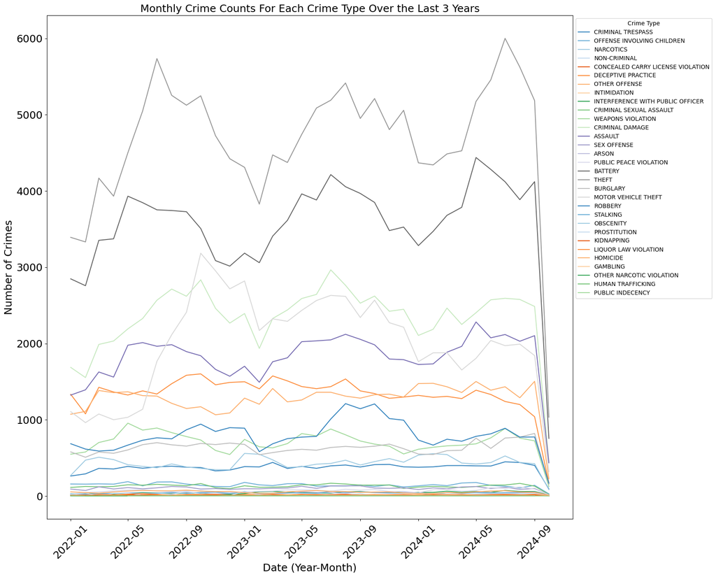

```python
# plot data
plt.figure(figsize=(14, 14))
n_distinct = res_df['Primary Type'].nunique()
colors = sns.color_palette("tab20c", n_colors=n_distinct)
sns.lineplot(data=res_df, x="Date", y="count", hue="Primary Type", palette=colors)

plt.title("Monthly Crime Counts For Each Crime Type Over the Last 3 Years", fontsize=18)
plt.xlabel("Date (Year-Month)", fontsize=18)
plt.ylabel("Number of Crimes", fontsize=18)
plt.xticks(rotation=45, fontsize=18)
plt.yticks(fontsize=18)
plt.tight_layout()

plt.legend(title="Crime Type", bbox_to_anchor=(1, 1), loc='upper left')
plt.show()
```

```python
# assuming the question is asking for a plot with one line that counts all crimes each month regardless of type:

# filter for past 3 years assuming 2024 is starting year
res_rows = crimes_df.filter(F.col("Year").isin([2022, 2023, 2024]))
# group by Year and Month and count, then sort by date for plotting
res_rows = res_rows.groupBy("Year", "Month").count().orderBy("Year", "Month")
# convert to pandas df for plotting with matplot and make a column for date (set everything to first of each month)
res_df = res_rows.toPandas()
res_df['Date'] = pd.to_datetime(res_df['Year'].astype(str) + '-' + res_df['Month'] + '-01')
res_df = res_df.sort_values(by='Date')
```

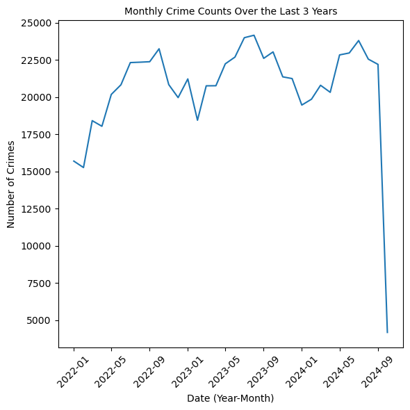

```python
# plot data
plt.figure(figsize=(6, 6))
plt.plot(res_df["Date"], res_df["count"])
plt.title("Monthly Crime Counts Over the Last 3 Years", fontsize=10)
plt.xlabel("Date (Year-Month)", fontsize=10)
plt.ylabel("Number of Crimes", fontsize=10)
plt.xticks(rotation=45, fontsize=10)
plt.yticks(fontsize=10)
plt.tight_layout()
plt.show()
```

```python
# 4d: year over year comparison for top 5 crime types over last 3 years (assuming top 5 crime types for the last
# 3 years specifically not out of the whole dataset)

# filter for crimes occuring in past 3 years (assuming 2024 is current year so also filter for 2023 and 2022)
res_rows = crimes_df.filter(F.col("Year").isin([2022, 2023, 2024]))

# group crimes by year and count occurrences per year
res_rows = res_rows.groupBy("Year", "Primary Type").agg(F.count("*").alias("count"))

# find top 5 by counting occurrences over all past 3 years and getting top 5 rows of counts
res_total = res_rows.groupBy("Primary Type").agg(F.sum("count").alias("total"))
res_total = res_total.orderBy(col("total").desc())
top_5 = res_total.limit(5).select("Primary Type")
```

```python
res = res_rows.join(top_5, on="Primary Type", how="inner")
res_df = res.toPandas()
res_df = res_df.sort_values(by='Year')
```

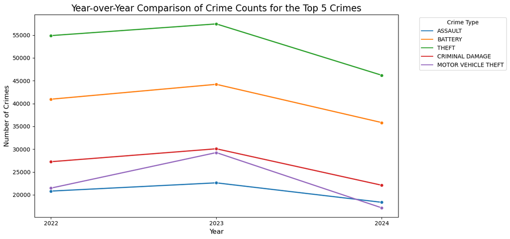

```python
# plotting a line graph time series with a line for each crime
plt.figure(figsize=(10, 6))

sns.lineplot(data=res_df, x="Year", y="count", hue="Primary Type", marker="o", linewidth=2)


plt.title("Year-over-Year Comparison of Crime Counts for the Top 5 Crimes", fontsize=16)
plt.xlabel("Year", fontsize=12)
plt.ylabel("Number of Crimes", fontsize=12)
plt.xticks([2022, 2023, 2024])  # Set the x-axis to display specific years if needed
plt.tight_layout()

plt.legend(title="Crime Type", bbox_to_anchor=(1.05, 1), loc='upper left')
plt.show()
```

[figure not shown]

```python
# plotting a bar graph for a different comparison lens

plt.figure(figsize=(12, 8))

sns.barplot(data=res_df, x="Year", y="count", hue="Primary Type", ci=None)

plt.title("Year-over-Year Comparison of Crime Counts by Type", fontsize=16)
plt.xlabel("Crime Type", fontsize=12)
plt.ylabel("Number of Crimes", fontsize=12)
plt.xticks(rotation=45, ha="right", fontsize=10)
plt.yticks(fontsize=10)
plt.tight_layout()

# Display the legend
plt.legend(title="Year", bbox_to_anchor=(1.05, 1), loc='upper left')

# Show the plot
plt.show()
```

## Question 5

```python
# 5a: community rank based on crime count

# group by community and count crimes then make a window function for ordering the crime ranks
ranks = crimes_df.groupBy("name").agg(F.count("*").alias("crimes_count"))
window = Window.orderBy(F.desc("crimes_count"))
ranks = ranks.withColumn("Rank", F.row_number().over(window))
results = ranks.select("name", "crimes_count", "Rank")

results.show(results.count(), truncate=False)
```

[output not shown]

```
+----------------------+------------+----+
|name                  |crimes_count|Rank|
+----------------------+------------+----+
|null                  |613530      |1   |
|Austin                |467396      |2   |
|Near North Side       |269714      |3   |
|South Shore           |249256      |4   |
|Humboldt Park         |234652      |5   |
|Near West Side        |232954      |6   |
|West Town             |222164      |7   |
|North Lawndale        |220182      |8   |
|Auburn Gresham        |213308      |9   |
|West Englewood        |212133      |10  |
|Roseland              |199457      |11  |
|Englewood             |194842      |12  |
|Loop[11]              |191381      |13  |
|Greater Grand Crossing|188227      |14  |
|Chicago Lawn          |182562      |15  |
|Chatham               |167123      |16  |
|Logan Square          |156307      |17  |
|Lake View             |155075      |18  |
|New City              |150807      |19  |
|West Garfield Park    |141430      |20  |
|East Garfield Park    |140498      |21  |
|Belmont Cragin        |138768      |22  |
|South Chicago         |138358      |23  |
|South Lawndale        |127199      |24  |
|West Pullman          |122727      |25  |
|Woodlawn              |120500      |26  |
|Lincoln Park          |117596      |27  |
|Rogers Park           |117505      |28  |
|Uptown                |111994      |29  |
|Grand Boulevard       |104991      |30  |
|West Ridge            |97624       |31  |
|Portage Park          |95869       |32  |
|Washington Heights    |90136       |33  |
|Irving Park           |84935       |34  |
|Douglas               |84387       |35  |
|Washington Park       |79579       |36  |
|Edgewater             |77049       |37  |
```

[output cut: 27 more lines]

```
|Clearing              |30263       |65  |
|West Elsdon           |29086       |66  |
|Armour Square         |28855       |67  |
|Beverly               |27507       |68  |
|Archer Heights        |27392       |69  |
|North Park            |25653       |70  |
|Fuller Park           |24875       |71  |
|Montclare             |18139       |72  |
|Oakland               |17904       |73  |
|Hegewisch             |17083       |74  |
|Mount Greenwood       |16919       |75  |
|Forest Glen           |14133       |76  |
|Burnside              |11229       |77  |
|Edison Park           |7578        |78  |
+----------------------+------------+----+
```

```python
# 5b: rolling 7 day crime count per community


# window for calculating the rolling sum
# group by community and date to get the sum
window = Window.partitionBy("name").orderBy("Date").rowsBetween(-7, 0)
rolling = crimes_df.withColumn(
    "Rolling",
    F.sum(F.when(F.col("Date").isNotNull(), 1).otherwise(0)).over(window)
)
```

```python
results = rolling.select("name", "Date", "Rolling")

results.show(10, truncate=False)
```

```
[Stage 168:>                                                        (0 + 1) / 1]
```

```
+-------+----------+-------+
|name   |Date      |Rolling|
+-------+----------+-------+
|Ashburn|2001-01-01|1      |
|Ashburn|2001-01-01|2      |
|Ashburn|2001-01-01|3      |
|Ashburn|2001-01-01|4      |
|Ashburn|2001-01-25|5      |
|Ashburn|2001-02-01|6      |
|Ashburn|2001-02-13|7      |
|Ashburn|2001-02-21|8      |
|Ashburn|2001-02-23|8      |
|Ashburn|2001-03-16|8      |
+-------+----------+-------+
only showing top 10 rows
```

```python
copy_df = crimes_df.groupBy("name", "Date").agg(F.count("*").alias("count"))

# 5c: 7 day average and sum per community

window = Window.partitionBy("name").orderBy("Date").rowsBetween(-7, 0)


# Calculate the 7-day moving average
moving_avg = copy_df.withColumn("Moving Average", F.avg("count").over(window))

# Calculate the cumulative sum
window2 = Window.partitionBy("name").orderBy("Date").rowsBetween(Window.unboundedPreceding, Window.currentRow)
results_df = moving_avg.withColumn("Cumulative Sum", F.sum("count").over(window2))
```

```python
# select relevant columns
results = results_df.select("name", "Date",
                          "Moving Average", "Cumulative Sum")

results.show(10, truncate=False)
```

```
[Stage 251:======================================>                  (6 + 3) / 9]
```

```
+-------+----------+------------------+--------------+
|name   |Date      |Moving Average    |Cumulative Sum|
+-------+----------+------------------+--------------+
|Ashburn|2001-01-01|4.0               |4             |
|Ashburn|2001-01-25|2.5               |5             |
|Ashburn|2001-02-01|2.0               |6             |
|Ashburn|2001-02-13|1.75              |7             |
|Ashburn|2001-02-21|1.6               |8             |
|Ashburn|2001-02-23|1.5               |9             |
|Ashburn|2001-03-16|1.4285714285714286|10            |
|Ashburn|2001-04-23|1.375             |11            |
|Ashburn|2001-05-09|1.0               |12            |
|Ashburn|2001-05-27|1.0               |13            |
+-------+----------+------------------+--------------+
only showing top 10 rows
```

```python
# 5d: cross-tab crime type vs location description and make heatmap

# make contingency table
cross_tab_df = crimes_df.crosstab("Primary Type", "Location Description").fillna(0)

# convert for plotting
cross_tab_pd = cross_tab_df.toPandas()
cross_tab_pd.set_index(cross_tab_pd.columns[0], inplace=True)
```

```python
cross_tab_pd.head(10)
```

| Primary Type_Location Description | "CTA ""L"" PLATFORM" | "CTA ""L"" TRAIN" | ABANDONED BUILDING | AIRCRAFT | AIRPORT BUILDING NON-TERMINAL - NON-SECURE AREA | AIRPORT BUILDING NON-TERMINAL - SECURE AREA | AIRPORT EXTERIOR - NON-SECURE AREA | AIRPORT EXTERIOR - SECURE AREA | AIRPORT PARKING LOT | AIRPORT TERMINAL LOWER LEVEL - NON-SECURE AREA | ... | VEHICLE NON-COMMERCIAL | VEHICLE-COMMERCIAL | VEHICLE-COMMERCIAL - ENTERTAINMENT/PARTY BUS | VEHICLE-COMMERCIAL - TROLLEY BUS | VESTIBULE | WAREHOUSE | WOODED AREA | YARD | YMCA | null |
| --- | --- | --- | --- | --- | --- | --- | --- | --- | --- | --- | --- | --- | --- | --- | --- | --- | --- | --- | --- | --- | --- |
| CRIMINAL TRESPASS | 0 | 0 | 1703 | 3 | 95 | 9 | 67 | 50 | 40 | 1002 | ... | 1459 | 83 | 0 | 0 | 0 | 442 | 0 | 0 | 0 | 4 |
| OFFENSE INVOLVING CHILDREN | 0 | 0 | 27 | 1 | 2 | 3 | 2 | 0 | 0 | 4 | ... | 312 | 10 | 0 | 2 | 0 | 3 | 0 | 0 | 0 | 8 |
| NARCOTICS | 0 | 0 | 3019 | 9 | 14 | 11 | 11 | 7 | 6 | 18 | ... | 22401 | 173 | 0 | 0 | 0 | 104 | 0 | 0 | 0 | 1 |
| RITUALISM | 0 | 0 | 0 | 0 | 0 | 0 | 0 | 0 | 0 | 0 | ... | 1 | 0 | 0 | 0 | 0 | 0 | 0 | 0 | 0 | 0 |
| CRIMINAL SEXUAL ASSAULT | 0 | 0 | 49 | 2 | 2 | 0 | 3 | 0 | 3 | 1 | ... | 245 | 0 | 0 | 0 | 0 | 4 | 0 | 0 | 0 | 11 |
| INTIMIDATION | 0 | 0 | 0 | 0 | 0 | 0 | 1 | 0 | 0 | 1 | ... | 12 | 1 | 0 | 0 | 0 | 5 | 0 | 0 | 0 | 3 |
| OBSCENITY | 0 | 0 | 0 | 0 | 0 | 0 | 0 | 0 | 0 | 0 | ... | 4 | 0 | 0 | 0 | 0 | 0 | 0 | 0 | 0 | 1 |
| MOTOR VEHICLE THEFT | 0 | 0 | 20 | 1 | 91 | 5 | 107 | 11 | 392 | 4 | ... | 4187 | 87 | 1 | 0 | 0 | 89 | 0 | 0 | 0 | 9 |
| GAMBLING | 0 | 0 | 97 | 0 | 0 | 0 | 0 | 0 | 0 | 0 | ... | 2 | 0 | 0 | 0 | 0 | 1 | 0 | 0 | 0 | 0 |
| OTHER OFFENSE | 0 | 0 | 500 | 37 | 55 | 63 | 45 | 31 | 30 | 37 | ... | 6494 | 112 | 2 | 1 | 0 | 330 | 0 | 0 | 0 | 136 |

10 rows × 219 columns

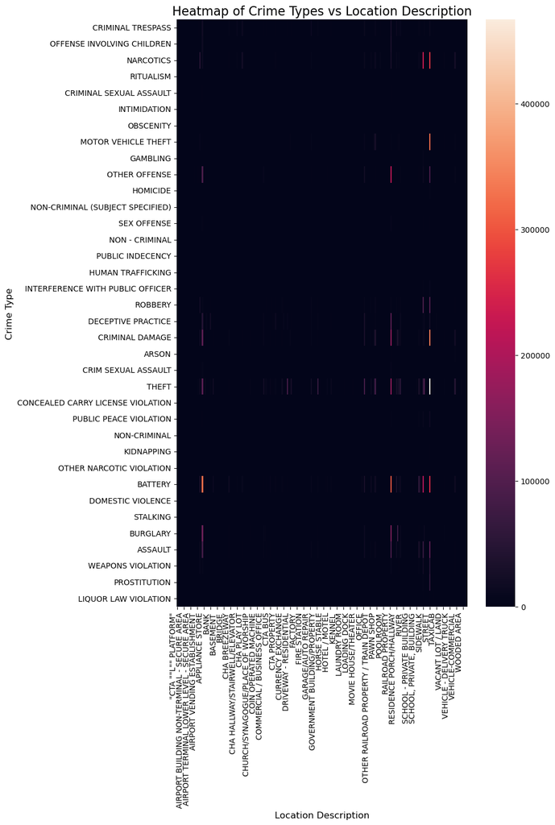

```python
plt.figure(figsize=(10, 15))


sns.heatmap(cross_tab_pd)


plt.title("Heatmap of Crime Types vs Location Description", fontsize=16)
plt.xlabel("Location Description", fontsize=12)
plt.ylabel("Crime Type", fontsize=12)
plt.xticks(rotation=90, ha='right')
plt.yticks(rotation=0)

plt.tight_layout()
plt.show()
```

## Question 6

```python
# 6a: load in covid cases data

# copy file path from the datasets bucket
gcs_path = "gs://msca-31013-bdp-ap-datasets/COVID-19_Daily_Cases__Deaths__and_Hospitalizations_-_Historical_20241105.csv"

# Read the CSV file using path
covid_df = spark.read.csv(gcs_path, header=True, inferSchema=True)

# display first few rows of data frame to check loading
covid_df.show(10)
```

```
24/11/11 02:35:18 WARN org.apache.spark.sql.catalyst.util.package: Truncated the string representation of a plan since it was too large. This behavior can be adjusted by setting 'spark.sql.debug.maxToStringFields'.
```

```
+----------+-------------+--------------+------------------------+----------------+-----------------+-----------------+-----------------+-----------------+-----------------+-----------------+----------------+-------------------+--------------+------------+----------------------+--------------+------…
|      Date|Cases - Total|Deaths - Total|Hospitalizations - Total|Cases - Age 0-17|Cases - Age 18-29|Cases - Age 30-39|Cases - Age 40-49|Cases - Age 50-59|Cases - Age 60-69|Cases - Age 70-79|Cases -  Age 80+|Cases - Age Unknown|Cases - Female|Cases - Male|Cases - Unknown Gender|Cases - Latinx|Cases …
+----------+-------------+--------------+------------------------+----------------+-----------------+-----------------+-----------------+-----------------+-----------------+-----------------+----------------+-------------------+--------------+------------+----------------------+--------------+------…
|03/06/2020|            3|             0|                       2|               0|                0|                0|                2|                0|                1|                0|               0|                  0|             0|           3|                     0|             0|      …
|03/07/2020|            3|             0|                       3|               0|                0|                0|                0|                1|                0|                2|               0|                  0|             3|           0|                     0|             0|      …
|03/14/2020|           31|             0|                       9|               0|                9|                2|                7|                6|                3|                3|               1|                  0|            18|          13|                     0|             2|      …
|03/12/2020|           21|             0|                       7|               0|                6|                5|                2|                4|                3|                1|               0|                  0|             6|          15|                     0|             2|      …
|03/03/2020|            0|             0|                       3|               0|                0|                0|                0|                0|                0|                0|               0|                  0|             0|           0|                     0|             0|      …
|03/09/2020|            5|             0|                       3|               3|                0|                0|                0|                0|                0|                1|               1|                  0|             3|           2|                     0|             2|      …
|03/01/2020|            0|             0|                       2|               0|                0|                0|                0|                0|                0|                0|               0|                  0|             0|           0|                     0|             0|      …
|03/08/2020|            3|             0|                       7|               0|                0|                1|                1|                0|                0|                1|               0|                  0|             1|           2|                     0|             1|      …
|03/02/2020|            0|             0|                       1|               0|                0|                0|                0|                0|                0|                0|               0|                  0|             0|           0|                     0|             0|      …
|03/11/2020|           13|             0|                       7|               0|                4|                1|                3|                3|                2|                0|               0|                  0|             4|           9|                     0|             2|      …
+----------+-------------+--------------+------------------------+----------------+-----------------+-----------------+-----------------+-----------------+-----------------+-----------------+----------------+-------------------+--------------+------------+----------------------+--------------+------…
only showing top 10 rows
```

```python
# 6b: create summarized daily crimes table

# group by crime type and date then count
summarized_df = crimes_df.groupBy("Date", "Primary Type").agg(F.count("*").alias("Total Crime Count"))
summarized_df = summarized_df.orderBy("Date")

# check summarized data
summarized_df.show(10, truncate = False)
```

```
[Stage 42:=============================================>            (7 + 2) / 9]
```

```
+----------+----------------------+-----------------+
|Date      |Primary Type          |Total Crime Count|
+----------+----------------------+-----------------+
|2001-01-01|BATTERY               |296              |
|2001-01-01|MOTOR VEHICLE THEFT   |60               |
|2001-01-01|CRIMINAL TRESPASS     |29               |
|2001-01-01|BURGLARY              |66               |
|2001-01-01|STALKING              |1                |
|2001-01-01|LIQUOR LAW VIOLATION  |3                |
|2001-01-01|PUBLIC PEACE VIOLATION|5                |
|2001-01-01|PROSTITUTION          |5                |
|2001-01-01|THEFT                 |412              |
|2001-01-01|CRIMINAL DAMAGE       |233              |
+----------+----------------------+-----------------+
only showing top 10 rows
```

```python
# 6c:
# select relevant columns from covid df
# need to update covid dates to have the same format as crimes date
covid_df = covid_df.select("Date", "Cases - Total", "Deaths - Total")
covid_copy_df = covid_df.withColumn("Date", F.to_date("Date", "MM/dd/yyyy"))
covid_copy_df = covid_copy_df.withColumnRenamed("Date", "CovidDate")

# check that the dates updated
covid_copy_df.show(10)
```

```
+----------+-------------+--------------+
| CovidDate|Cases - Total|Deaths - Total|
+----------+-------------+--------------+
|2020-03-06|            3|             0|
|2020-03-07|            3|             0|
|2020-03-14|           31|             0|
|2020-03-12|           21|             0|
|2020-03-03|            0|             0|
|2020-03-09|            5|             0|
|2020-03-01|            0|             0|
|2020-03-08|            3|             0|
|2020-03-02|            0|             0|
|2020-03-11|           13|             0|
+----------+-------------+--------------+
only showing top 10 rows
```

```python
# filter summarized df for dates
crimes_copy_df = summarized_df.filter(F.col("Date") >= "2020-01-01")
covid_copy_df = covid_copy_df.filter(F.col("CovidDate") >= "2020-01-01")
```

```python
# join dfs
new_df = crimes_copy_df.join(covid_copy_df, covid_copy_df.CovidDate == crimes_copy_df.Date, how="left")

# need only one date column
new_df = new_df.select("Date", "Primary Type", "Total Crime Count", "Cases - Total", "Deaths - Total")

# check new df is correct
new_df.show(10, truncate = False)
```

```
[Stage 104:===============================================>       (13 + 2) / 15]
```

```
+----------+------------------+-----------------+-------------+--------------+
|Date      |Primary Type      |Total Crime Count|Cases - Total|Deaths - Total|
+----------+------------------+-----------------+-------------+--------------+
|2020-07-15|ASSAULT           |55               |268          |7             |
|2020-08-21|CRIMINAL DAMAGE   |66               |430          |5             |
|2020-04-04|DECEPTIVE PRACTICE|44               |326          |22            |
|2020-06-07|NARCOTICS         |10               |110          |20            |
|2023-08-21|ASSAULT           |75               |211          |0             |
|2020-05-07|DECEPTIVE PRACTICE|30               |939          |49            |
|2020-04-02|THEFT             |83               |436          |15            |
|2020-06-25|WEAPONS VIOLATION |16               |249          |11            |
|2023-08-10|BURGLARY          |12               |133          |0             |
|2022-09-13|ASSAULT           |66               |494          |2             |
+----------+------------------+-----------------+-------------+--------------+
only showing top 10 rows
```

## 6D: EDA

```python
from pyspark.ml.stat import Correlation
from pyspark.ml.feature import VectorAssembler
```

```python
new_df.printSchema()
```

```
root
 |-- Date: date (nullable = true)
 |-- Primary Type: string (nullable = true)
 |-- Total Crime Count: long (nullable = false)
 |-- Cases - Total: integer (nullable = true)
 |-- Deaths - Total: integer (nullable = true)
```

```python
new_df = new_df.withColumn("Total Crime Count", col("Total Crime Count").cast("int"))
```

```python
new_df.printSchema()
```

```
root
 |-- Date: date (nullable = true)
 |-- Primary Type: string (nullable = true)
 |-- Total Crime Count: integer (nullable = false)
 |-- Cases - Total: integer (nullable = true)
 |-- Deaths - Total: integer (nullable = true)
```

```python
# build a correlation matrix
numeric_columns = [col for col, dtype in new_df.dtypes if dtype in ('int', 'double')]
vec_assembler = VectorAssembler(inputCols=numeric_columns, outputCol="features")
df_with_features = vec_assembler.transform(new_df.dropna(subset=numeric_columns))

# Step 3: Calculate the correlation matrix
matrix = Correlation.corr(df_with_features, "features").head()[0]

# Step 4: Convert the correlation matrix to a Pandas DataFrame for easier viewing
corr_matrix = matrix.toArray()
corr_df = pd.DataFrame(corr_matrix, columns=numeric_columns, index=numeric_columns)

# Step 5: Show the correlation matrix
print(corr_df)
```

```
                   Total Crime Count  Cases - Total  Deaths - Total
Total Crime Count           1.000000      -0.027125       -0.051529
Cases - Total              -0.027125       1.000000        0.405391
Deaths - Total             -0.051529       0.405391        1.000000
```

##### The correlation matrix shows a negative correlation between total covid cases and total crime count as well as a negative correlation between total covid deaths and total crime count. This suggests that as total covid cases and total deaths increase, total crimes decrease. However, the correlation varies are very small so further analysis is necessary.

```python
# count total crime and total covid cases for each day
total_crime = new_df.groupBy("Date").agg(
    F.sum("Total Crime Count").alias("Total Crime Count"),
    F.sum("Cases - Total").alias("Total COVID Cases")
)

total_crime.show(10)
```

```
[Stage 151:===============================>                         (5 + 4) / 9]
```

```
+----------+-----------------+-----------------+
|      Date|Total Crime Count|Total COVID Cases|
+----------+-----------------+-----------------+
|2021-08-27|              674|            10260|
|2023-07-15|              789|              665|
|2021-01-27|              518|            13140|
|2021-11-13|              589|             8106|
|2020-08-24|              637|             8864|
|2023-06-22|              785|             1260|
|2024-09-18|              716|             null|
|2021-06-22|              635|              704|
|2022-03-28|              602|             7040|
|2021-12-18|              577|            60258|
+----------+-----------------+-----------------+
only showing top 10 rows
```

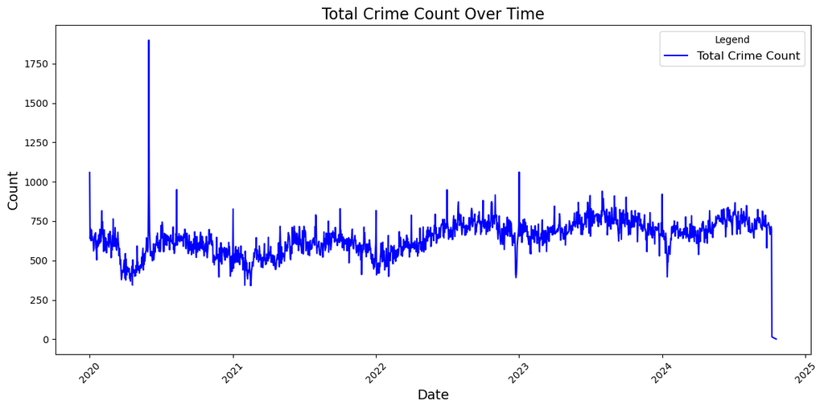

```python
df_pd = total_crime.toPandas()

# Fill missing COVID cases with 0
df_pd['Total COVID Cases'] = df_pd['Total COVID Cases'].fillna(0)

df_pd['Date'] = pd.to_datetime(df_pd['Date'])
df_pd.set_index('Date', inplace=True)


plt.figure(figsize=(12, 6))
sns.lineplot(data=df_pd, x=df_pd.index, y='Total Crime Count', label='Total Crime Count', color='blue')
#sns.lineplot(data=df_pd, x=df_pd.index, y='Total COVID Cases', label='Total COVID Cases', color='red')

plt.title('Total Crime Count Over Time', fontsize=16)
plt.xlabel('Date', fontsize=14)
plt.ylabel('Count', fontsize=14)
plt.xticks(rotation=45)
plt.legend(title='Legend', fontsize=12)
plt.tight_layout()

plt.show()
```

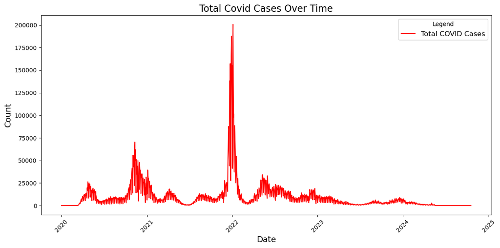

```python
plt.figure(figsize=(12, 6))
#sns.lineplot(data=df_pd, x=df_pd.index, y='Total Crime Count', label='Total Crime Count', color='blue')
sns.lineplot(data=df_pd, x=df_pd.index, y='Total COVID Cases', label='Total COVID Cases', color='red')

plt.title('Total Covid Cases Over Time', fontsize=16)
plt.xlabel('Date', fontsize=14)
plt.ylabel('Count', fontsize=14)
plt.xticks(rotation=45)
plt.legend(title='Legend', fontsize=12)
plt.tight_layout()

plt.show()
```

##### We see a spike in COVID cases during 2022 and a smaller spike in cases during late 2020/early 2021. Despite this increase in cases, we see a rather stable trend line in total crime cases over the same period of time, with the exception of a sharp spike mid-2020. It may be the case that total crime counts may not be associated with the amount of COVID cases.

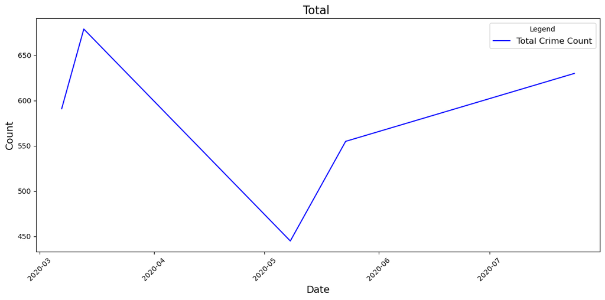

```python
df_pd = total_crime.toPandas()

df_pd['Total COVID Cases'] = df_pd['Total COVID Cases'].fillna(0)

df_pd['Date'] = pd.to_datetime(df_pd['Date'])
df_pd.sort_values(by='Date', ascending=True)
df_pd = df_pd[(df_pd['Date'] >= '2020-03-01') & (df_pd['Date'] <= '2020-08-01')].head()
df_pd.set_index('Date', inplace=True)

plt.figure(figsize=(12, 6))
sns.lineplot(data=df_pd, x=df_pd.index, y='Total Crime Count', label='Total Crime Count', color='blue')

plt.title('Total ', fontsize=16)
plt.xlabel('Date', fontsize=14)
plt.ylabel('Count', fontsize=14)
plt.xticks(rotation=45)
plt.legend(title='Legend', fontsize=12)
plt.tight_layout()

plt.show()
```

```python
filtered_df = new_df.filter(col("PRIMARY TYPE").isin(["ASSAULT", "BATTERY", "THEFT",
                                                "MOTOR VEHICLE THEFT", "CRIMINAL DAMAGE"]))
```

```python
filtered_df = filtered_df.toPandas()
```

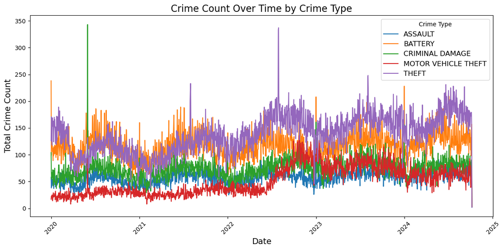

```python
crime_counts = filtered_df.groupby(['Date', 'Primary Type'])['Total Crime Count'].sum().reset_index()


plt.figure(figsize=(12, 6))
sns.lineplot(data=crime_counts, x='Date', y='Total Crime Count', hue='Primary Type')


plt.title('Crime Count Over Time by Crime Type', fontsize=16)
plt.xlabel('Date', fontsize=14)
plt.ylabel('Total Crime Count', fontsize=14)
plt.xticks(rotation=45)
plt.legend(title='Crime Type', fontsize=12)
plt.tight_layout()


plt.show()
```

##### For each of the top 5 primary crime types, the total daily crime count over time generally remains stable with a slight increasing trend during recent years.

```python
filtered_df2 = crimes_df.filter(col("PRIMARY TYPE").isin(["ASSAULT", "BATTERY", "THEFT",
                                                "MOTOR VEHICLE THEFT", "CRIMINAL DAMAGE"]))
```

```python
result_df = filtered_df2.groupBy('Primary Type', 'Year').agg(F.count('*').alias('Total Crime Count'))
```

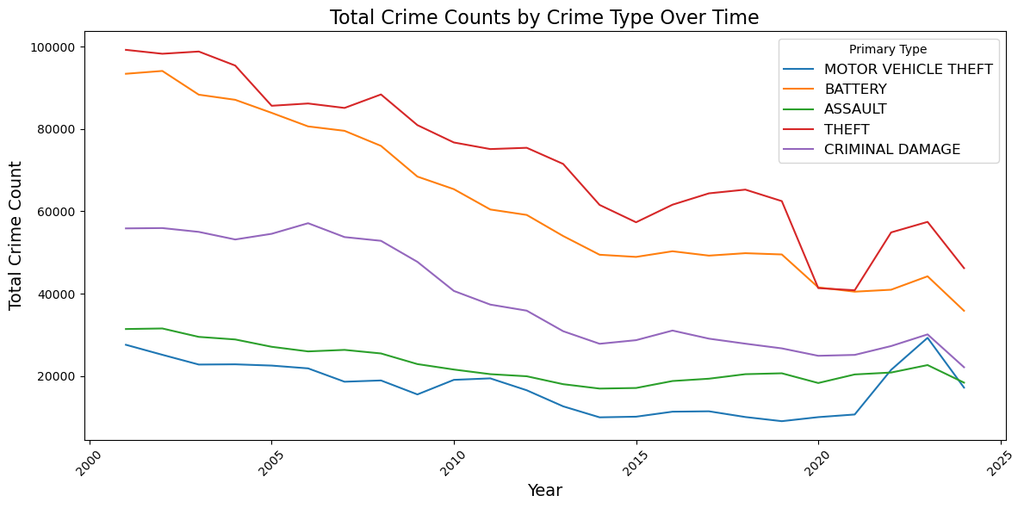

```python
result_pd = result_df.toPandas()

plt.figure(figsize=(12, 6))

sns.lineplot(data=result_pd, x='Year', y='Total Crime Count', hue='Primary Type')

plt.title('Total Crime Counts by Crime Type Over Time', fontsize=16)
plt.xlabel('Year', fontsize=14)
plt.ylabel('Total Crime Count', fontsize=14)
plt.xticks(rotation=45)
plt.legend(title='Primary Type', fontsize=12)
plt.tight_layout()

plt.show()
```

##### Over time, there is a general decrease in crimes counts per year for the top 5 crime types. However, post 2020 (after COVID) there is a slight increasing trend and then the trend returns back to decreasing.

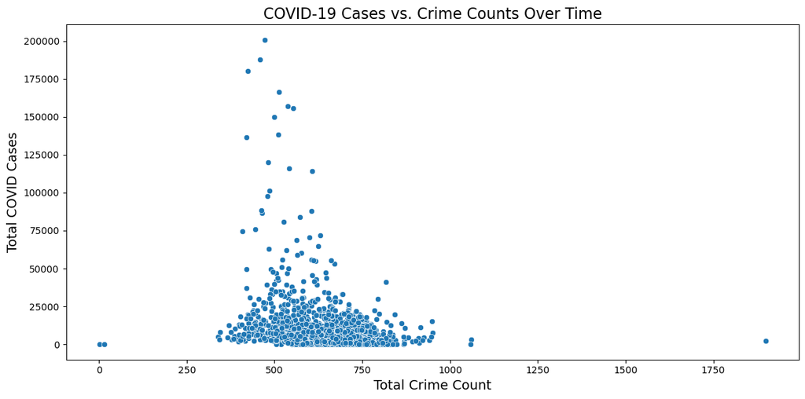

```python
df_pd = total_crime.toPandas()

df_pd['Total COVID Cases'] = df_pd['Total COVID Cases'].fillna(0)

df_pd['Date'] = pd.to_datetime(df_pd['Date'])
df_pd.set_index('Date', inplace=True)


plt.figure(figsize=(12, 6))
sns.scatterplot(data=df_pd, y='Total COVID Cases', x='Total Crime Count', palette='viridis')

plt.title("COVID-19 Cases vs. Crime Counts Over Time", fontsize=16)
plt.ylabel("Total COVID Cases", fontsize=14)
plt.xlabel("Total Crime Count", fontsize=14)
plt.tight_layout()

plt.show()
```

##### Higher COVID cases tend to occur at the lower end of total daily crime count values.

```python
filtered_df3 = crimes_df.filter(col("PRIMARY TYPE").isin(["ASSAULT", "BATTERY", "THEFT",
                                                "MOTOR VEHICLE THEFT", "CRIMINAL DAMAGE"]))

filtered_df3 = filtered_df3.filter(F.col("Date") < "2020-03-01")
```

```python
crime_by_type = filtered_df3.groupBy("Primary Type").agg(F.count("*").alias("Crime Count"))

total_crimes_count = filtered_df3.agg(F.count("*").alias("Total Crimes")).first()["Total Crimes"]

proportion = crime_by_type.withColumn(
    "Proportion",
    F.col("Crime Count") / total_crimes_count
)
proportion.orderBy("Proportion").show()
```

```
[Stage 224:========================================>              (11 + 4) / 15]
```

```
+-------------------+-----------+-------------------+
|       Primary Type|Crime Count|         Proportion|
+-------------------+-----------+-------------------+
|MOTOR VEHICLE THEFT|     325898|0.07458234545637626|
|            ASSAULT|     444623|0.10175277597239132|
|    CRIMINAL DAMAGE|     805242|0.18428108494063583|
|            BATTERY|    1295016|0.29636674874818064|
|              THEFT|    1498861|0.34301704488241597|
+-------------------+-----------+-------------------+
```

```python
filtered_df4 = crimes_df.filter(col("PRIMARY TYPE").isin(["ASSAULT", "BATTERY", "THEFT",
                                                "MOTOR VEHICLE THEFT", "CRIMINAL DAMAGE"]))
filtered_df4 = filtered_df4.filter(F.col("Date") >= "2020-03-01")
```

```python
crime_by_type = filtered_df4.groupBy("Primary Type").agg(F.count("*").alias("Crime Count"))

total_crimes_count = filtered_df4.agg(F.count("*").alias("Total Crimes")).first()["Total Crimes"]

proportion = crime_by_type.withColumn(
    "Proportion",
    F.col("Crime Count") / total_crimes_count
)
proportion.orderBy("Proportion").show()
```

```
[Stage 232:========================================>              (11 + 4) / 15]
```

```
+-------------------+-----------+-------------------+
|       Primary Type|Crime Count|         Proportion|
+-------------------+-----------+-------------------+
|MOTOR VEHICLE THEFT|      87097|0.11796774263455016|
|            ASSAULT|      97475| 0.1320241307198041|
|    CRIMINAL DAMAGE|     125864|0.17047535459263835|
|            BATTERY|     195975|0.26543656340408933|
|              THEFT|     231901| 0.3140962086489181|
+-------------------+-----------+-------------------+
```

#### Among cases for the top 5 primary crime types, theft remained the highest proportion of the crimes and motor vehicle theft remained the lowest. While the order of the proportions remained the same, the proportion for motor vehicle theft and assault increased while it decreased for the other three crime types after the first lockdown.